# Kaggle - House Prices

Step 1: Data Management

Gimme the Prize

2020-01-24

This is an analysis of the *Ames* dataset for the Kaggle competition [House Prices: Advanced Regression Techniques](https://www.kaggle.com/c/house-prices-advanced-regression-techniques).  
Kaggle’s House Prices competition challenges participants to predict the final sale price of 1,459 homes sold in Ames, IA from 2006 to 2010. The original dataset was published by Dean De Cock in [Ames, Iowa: Alternative to the Boston Housing Data as an End of Semester Regression Project](https://ww2.amstat.org/publications/jse/v19n3/decock.pdf). The source data set for the competition contains 2,919 observations and 79 explanatory variables (23 nominal, 23 ordinal, 14 discrete, and 19 continuous) involved in assessing home values. Kaggle segmented the data set into a training set consisting of 1,460 observations and a test data set consisting of 1,459 observations with the final sale price excluded. Competitors build a predictive model with the training set, then apply the model to the test set to produce a submission file consisting of the observation id and the predicted sale price. Kaggle evaluates submissions on the root-mean-squared-error (RMSE) between the log of the predicted sales price and the log of the observed sales price.

This document addresses initial data management: data cleaning and imputation.

# Setup

```r
library(tidyverse)
library(gridExtra)
library(mice)
```

# Load Data

Load train and test, then combine to create a single data set for exploration and feature engineering.

```r
# "NA" is an actual data label - only allow empty string "" for `NA`
d.train <- read_csv("./train.csv", na = c("")) %>% mutate(Set = "train")
d.train <- rename(d.train, !!c(X1stFlrSF = "1stFlrSF",
                               X2ndFlrSF = "2ndFlrSF",
                               X3SsnPorch = "3SsnPorch"))
d.test <- read_csv("./test.csv", na = c("")) %>% mutate(SalePrice = NA, Set = "test")
d.test <- rename(d.test, !!c(X1stFlrSF = "1stFlrSF",
                             X2ndFlrSF = "2ndFlrSF",
                             X3SsnPorch = "3SsnPorch"))
d <- rbind(d.train, d.test)
d <- d %>% select(Set, Id, SalePrice, sort(names(d))) %>% data.frame()
```

Define the ordinal factor variable levels from the [codebook](https://www.kaggle.com/c/house-prices-advanced-regression-techniques/download/data_description.txt). I count 19 ordinal variables, not 23 as indicated by De Cock.  
`OverallQual` and `OverallCond` could be ordinal or numeric. With experimentation, it appears they perform slightly better as numeric, so I removed them from this list.

```r
OF.levels <- list(
  BsmtCond = c('NA', 'Po', 'Fa', 'TA', 'Gd', 'Ex'),
  BsmtExposure = c('NA', 'No', 'Mn', 'Av', 'Gd'),
  BsmtFinType1 = c('NA', 'Unf', 'LwQ', 'Rec', 'BLQ', 'ALQ', 'GLQ'),
  BsmtFinType2 = c('NA', 'Unf', 'LwQ', 'Rec', 'BLQ', 'ALQ', 'GLQ'),
  BsmtQual = c('NA', 'Po', 'Fa', 'TA', 'Gd', 'Ex'),
  Electrical = c('FuseP', 'FuseF', 'FuseA', 'Mix', 'SBrkr'),
  ExterQual = c('Po', 'Fa', 'TA', 'Gd', 'Ex'),
  ExterCond = c('Po', 'Fa', 'TA', 'Gd', 'Ex'),
  Fence = c('NA', 'MnWw', 'MnPrv', 'GdWo', 'GdPrv'),
  FireplaceQu = c('NA', 'Po', 'Fa', 'TA', 'Gd', 'Ex'),
  Functional = c('Sal', 'Sev', 'Maj2', 'Maj1', 'Mod', 'Min2', 'Min1', 'Typ'),
  GarageCond = c('NA', 'Po', 'Fa', 'TA', 'Gd', 'Ex'),
  GarageFinish = c('NA', 'Unf', 'RFn', 'Fin'),
  GarageQual = c('NA', 'Po', 'Fa', 'TA', 'Gd', 'Ex'),
  HeatingQC = c('Po', 'Fa', 'TA', 'Gd', 'Ex'),
  KitchenQual = c('Po', 'Fa', 'TA', 'Gd', 'Ex'),
  PoolQC = c('NA', 'Po', 'Fa', 'TA', 'Gd', 'Ex')
)
```

Define the nominal factor variable levels. I count 28 nominal variables, not 23 as indicated by De Cock

```r
UF.levels <- list(
  Alley = c('Grvl', 'Pave', 'NA'),
  BldgType = c('1Fam', '2FmCon', 'Duplx', 'TwnhsE', 'TwnhsI'),
  CentralAir = c('N', 'Y'),
  Condition1 = c('Artery', 'Feedr', 'Norm', 'RRNn', 'RRAn', 'PosN', 'PosA', 'RRNe', 'RRAe'),
  Condition2 = c('Artery', 'Feedr', 'Norm', 'RRNn', 'RRAn', 'PosN', 'PosA', 'RRNe', 'RRAe'),
  Exterior1st = c('AsbShng','AsphShn','BrkComm','BrkFace','CBlock','CemntBd','HdBoard',
                  'ImStucc','MetalSd','Other','Plywood','PreCast','Stone','Stucco',
                  'VinylSd','Wd Sdng','WdShing'),
  Exterior2nd = c('AsbShng','AsphShn','BrkComm','BrkFace','CBlock','CemntBd','HdBoard',
                  'ImStucc','MetalSd','Other','Plywood','PreCast','Stone','Stucco',
                  'VinylSd','Wd Sdng','WdShing'),
  Foundation = c('BrkTil', 'CBlock', 'PConc', 'Slab', 'Stone', 'Wood'),
  GarageType = c('2Types', 'Attchd', 'Basment', 'BuiltIn', 'CarPort', 'Detchd', 'NA'),
  Heating = c('Floor', 'GasA', 'GasW', 'Grav', 'OthW', 'Wall'),
  HouseStyle = c('1Story', '1.5Fin', '1.5Unf', '2Story', '2.5Fin', '2.5Unf', 'SFoyer', 'SLvl'),
  LandSlope = c('Gtl', 'Mod', 'Sev'),
  LotConfig = c('Inside', 'Corner', 'CulDSac', 'FR2', 'FR3'),
  LandContour = c('Lvl', 'Bnk', 'HLS', 'Low'),
  LotShape = c('Reg', 'IR1', 'IR2', 'IR3'),
  MasVnrType = c('BrkCmn', 'BrkFace', 'CBlock', 'Stone', 'None'),
  MoSold = 1:12,
  MiscFeature = c('Elev', 'Gar2', 'Othr', 'Shed', 'TenC', 'NA'),
  MSSubClass = c(20, 30, 40, 45, 50, 60, 70, 75, 80, 85, 90, 120, 150, 160, 180, 190),
  MSZoning = c('A', 'C', 'FV', 'I', 'RH', 'RL', 'RP', 'RM'),
  Neighborhood = c('Blmngtn','Blueste','BrDale','BrkSide','ClearCr','CollgCr',
                   'Crawfor','Edwards','Gilbert','IDOTRR','MeadowV','Mitchel',
                   'Names','NoRidge','NPkVill','NridgHt','NWAmes','OldTown',
                   'SWISU','Sawyer','SawyerW','Somerst','StoneBr','Timber',
                   'Veenker'),
  PavedDrive = c('Y', 'P', 'N'),
  RoofMatl = c('ClyTile','CompShg','Membran','Metal','Roll','Tar&Grv','WdShake','WdShngl'),
  RoofStyle = c('Flat', 'Gable', 'Gambrel', 'Hip', 'Mansard', 'Shed'),
  SaleCondition = c('Normal', 'Abnorml', 'AdjLand', 'Alloca', 'Family', 'Partial'),
  SaleType = c('WD','CWD','VWD','New','COD','Con','ConLw','ConLI','ConLD','Oth'),
  Street = c('Grvl', 'Pave'),
  Utilities = c('AllPub', 'NoSwr', 'NoSeWa', 'ELO')
)
```

# Clean Data

I’ll look at each feature and adjust the data type and/or factor levels as necessary so that the data is reconciled with the codebook.

```r
d$Id <- as.numeric(d$Id)
d$SalePrice <- as.numeric(d$SalePrice)
d$Alley <- parse_factor(d$Alley, levels = UF.levels$Alley)
d$BedroomAbvGr <- as.numeric(d$BedroomAbvGr)
```

BldgType levels do not match values in data description file. Doesn’t look like typos - the data codebook just does not match. Use the data file levels instead of the codebook levels.

```r
setdiff(unique(d$BldgType), OF.levels$BldgType)
```

```
## [1] "1Fam"   "2fmCon" "Duplex" "TwnhsE" "Twnhs"
```

```r
UF.levels$BldgType <- unique(d$BldgType)
d$BldgType <- parse_factor(d$BldgType, levels = UF.levels$BldgType)
```

```r
d$BsmtCond <- parse_factor(d$BsmtCond, levels = OF.levels$BsmtCond, ordered = TRUE) %>% fct_explicit_na("NA")
d$BsmtExposure <- parse_factor(d$BsmtExposure, levels = OF.levels$BsmtExposure, ordered = TRUE)
d$BsmtFinSF1 <- as.numeric(d$BsmtFinSF1)
d$BsmtFinSF2 <- as.numeric(d$BsmtFinSF2)
d$BsmtFinType1 <- parse_factor(d$BsmtFinType1, levels = OF.levels$BsmtFinType1, ordered = TRUE)
d$BsmtFinType2 <- parse_factor(d$BsmtFinType2, levels = OF.levels$BsmtFinType2, ordered = TRUE)
d$BsmtFullBath <- as.numeric(d$BsmtFullBath)
d$BsmtHalfBath <- as.numeric(d$BsmtHalfBath)
d$BsmtQual <- parse_factor(d$BsmtQual, levels = OF.levels$BsmtQual, ordered = TRUE) %>% fct_explicit_na("NA")
d$BsmtUnfSF <- as.numeric(d$BsmtUnfSF)
d$CentralAir <- parse_factor(d$CentralAir, levels = UF.levels$CentralAir)
d$Condition1 <- parse_factor(d$Condition1, levels = UF.levels$Condition1)
d$Condition2 <- parse_factor(d$Condition2, levels = UF.levels$Condition2)
```

`Electrical` includes `NA`s coded as “NA”.

```r
d$Electrical <- ifelse(d$Electrical == "NA", NA, d$Electrical)
d$Electrical <- parse_factor(d$Electrical, levels = OF.levels$Electrical, ordered = T, include_na = F)
```

```r
d$EnclosedPorch <- as.numeric(d$EnclosedPorch)
d$ExterCond <- parse_factor(d$ExterCond, levels = OF.levels$ExterCond, ordered = T)
```

`Exterior1st` includes `NA`s coded as “NA”.

```r
d$Exterior1st <- ifelse(d$Exterior1st == "NA", NA, d$Exterior1st)
d$Exterior1st <- parse_factor(d$Exterior1st, levels = UF.levels$Exterior1st, include_na = F)
```

`Exterior2nd` includes `NA`s coded as “NA”. Some values in `Exterior2nd` do not match the levels in the codebook.

```r
d$Exterior2nd <- ifelse(d$Exterior2nd == "NA", NA, d$Exterior2nd)
d <- d %>% mutate(Exterior2nd = case_when(Exterior2nd == "Wd Shng" ~ "WdShing",
                                          Exterior2nd == "CmentBd" ~ "CemntBd",
                                          Exterior2nd == "Brk Cmn" ~ "BrkFace",
                                          TRUE ~ Exterior2nd))
d$Exterior2nd <- parse_factor(d$Exterior2nd, levels = UF.levels$Exterior2nd, include_na = F)
```

```r
d$ExterQual <- parse_factor(d$ExterQual, levels = OF.levels$ExterQual, ordered = T)
d$Fence <- parse_factor(d$Fence, levels = OF.levels$Fence, ordered = T) %>% fct_explicit_na("NF")
d$FireplaceQu <- parse_factor(d$FireplaceQu, levels = OF.levels$FireplaceQu, ordered = T)
d$Fireplaces <- as.numeric(d$Fireplaces)
d$Foundation <- parse_factor(d$Foundation, levels = UF.levels$Foundation)
d$FullBath <- as.numeric(d$FullBath)
```

`Functional` includes `NA`s coded as “NA”.

```r
d$Functional <- ifelse(d$Functional == "NA", NA, d$Functional)
d$Functional <- parse_factor(d$Functional, levels = OF.levels$Functional, ordered = T, include_na = F)
```

```r
d$GarageArea <- as.numeric(d$GarageArea)
d$GarageCars <- as.numeric(d$GarageCars)
d$GarageCond <- parse_factor(d$GarageCond, levels = OF.levels$GarageCond, ordered = T)
d$GarageFinish <- parse_factor(d$GarageFinish, levels = OF.levels$GarageFinish, ordered = T)
d$GarageQual <- parse_factor(d$GarageQual, levels = OF.levels$GarageQual, ordered = T)
d$GarageType <- parse_factor(d$GarageType, levels = UF.levels$GarageType)
d$GarageYrBlt <- as.numeric(d$GarageYrBlt)
d$GrLivArea <- as.numeric(d$GrLivArea)
d$HalfBath <- as.numeric(d$HalfBath)
d$Heating <- parse_factor(d$Heating, levels = UF.levels$Heating)
d$HeatingQC <- parse_factor(d$HeatingQC, levels = OF.levels$HeatingQC, ordered = T)
d$HouseStyle <- parse_factor(d$HouseStyle, levels = UF.levels$HouseStyle)
d$KitchenAbvGr <- as.numeric(d$KitchenAbvGr)
```

`KitchenQual` includes `NA`s coded as “NA”.

```r
d$KitchenQual <- ifelse(d$KitchenQual == "NA", NA, d$KitchenQual)
d$KitchenQual <- parse_factor(d$KitchenQual, levels = OF.levels$KitchenQual, ordered = T, include_na = F)
```

```r
d$LandContour <- parse_factor(d$LandContour, levels = UF.levels$LandContour)
d$LandSlope <- parse_factor(d$LandSlope, levels = UF.levels$LandSlope)
d$LotArea <- as.numeric(d$LotArea)
d$LotConfig <- parse_factor(d$LotConfig, levels = UF.levels$LotConfig)
d$LotFrontage <- as.numeric(d$LotFrontage)
d$LotShape <- parse_factor(d$LotShape, levels = UF.levels$LotShape)
d$LowQualFinSF <- as.numeric(d$LowQualFinSF)
d$MasVnrArea <- as.numeric(d$MasVnrArea)
```

`MasVnrType` includes `NA`s coded as “NA”.

```r
d$MasVnrType <- ifelse(d$MasVnrType == "NA", NA, d$MasVnrType)
d$MasVnrType <- parse_factor(d$MasVnrType, levels = UF.levels$MasVnrType, include_na = F)
```

```r
d$MiscFeature <- parse_factor(d$MiscFeature, levels = UF.levels$MiscFeature) %>% fct_explicit_na("None")
d$MiscVal <- as.numeric(d$MiscVal)
d$MoSold <- parse_factor(as.character(d$MoSold), levels = UF.levels$MoSold)
d$MSSubClass <- parse_factor(as.character(d$MSSubClass), levels = UF.levels$MSSubClass)
```

`MSZoning` includes `NA`s coded as “NA”. `MSZoning` factor level “C” is coded as “C (all)” in the data. Correct the data.

```r
d$MSZoning <- ifelse(d$MSZoning == "NA", NA, d$MSZoning)
d$MSZoning <- parse_factor(ifelse(d$MSZoning == "C (all)", "C", d$MSZoning), levels = UF.levels$MSZoning, include_na = F)
```

`Neighborhood` factor level “NAmes” is coded as “Names” in the data. Correct the codebook.

```r
UF.levels$Neighborhood[UF.levels$Neighborhood == "Names"] <- "NAmes"
d$Neighborhood <- parse_factor(d$Neighborhood, levels = UF.levels$Neighborhood)
```

```r
d$OpenPorchSF <- as.numeric(d$OpenPorchSF)
#d$OverallCond <- parse_factor(as.character(d$OverallCond), levels = OF.levels$OverallCond, ordered = T)
#d$OverallQual <- parse_factor(as.character(d$OverallQual), levels = OF.levels$OverallQual, ordered = T)
d$PavedDrive <- parse_factor(d$PavedDrive, levels = UF.levels$PavedDrive)
d$PoolArea <- as.numeric(d$PoolArea)
d$PoolQC <- parse_factor(d$PoolQC, levels = OF.levels$PoolQC, ordered = T) %>% fct_explicit_na("NP")
d$RoofMatl <- parse_factor(d$RoofMatl, levels = UF.levels$RoofMatl)
d$RoofStyle <- parse_factor(d$RoofStyle, levels = UF.levels$RoofStyle)
d$SaleCondition <- parse_factor(d$SaleCondition, levels = UF.levels$SaleCondition)
```

`SaleType` includes `NA`s coded as “NA”.

```r
d$SaleType <- ifelse(d$SaleType == "NA", NA, d$SaleType)
d$SaleType <- parse_factor(d$SaleType, levels = UF.levels$SaleType, include_na = F)
```

```r
d$ScreenPorch <- as.numeric(d$ScreenPorch)
d$Street <- parse_factor(d$Street, levels = UF.levels$Street)
d$TotalBsmtSF <- as.numeric(d$TotalBsmtSF)
d$TotRmsAbvGrd <- as.numeric(d$TotRmsAbvGrd)
```

`Utilities` includes `NA`s coded as “NA”.

```r
d$Utilities <- ifelse(d$Utilities == "NA", NA, d$Utilities)
d$Utilities <- parse_factor(d$Utilities, levels = UF.levels$Utilities, include_na = F)
```

```r
d$WoodDeckSF <- as.numeric(d$WoodDeckSF)
d$X1stFlrSF <- as.numeric(d$X1stFlrSF)
d$X2ndFlrSF <- as.numeric(d$X2ndFlrSF)
d$X3SsnPorch <- as.numeric(d$X3SsnPorch)
d$YearBuilt <- as.numeric(d$YearBuilt)
d$YearRemodAdd <- as.numeric(d$YearRemodAdd)
d$YrSold <- as.numeric(d$YrSold)
```

How does it look?

```r
skimr::skim_to_wide(d)[, c(1:3, 9, 14, 16, 18, 19)] %>% knitr::kable()
```

| type | variable | missing | n_unique | p0 | p50 | p100 | hist |
| --- | --- | --- | --- | --- | --- | --- | --- |
| character | Set | 0 | 2 | NA | NA | NA | NA |
| factor | Alley | 0 | 3 | NA | NA | NA | NA |
| factor | BldgType | 0 | 5 | NA | NA | NA | NA |
| factor | BsmtCond | 0 | 5 | NA | NA | NA | NA |
| factor | BsmtExposure | 0 | 5 | NA | NA | NA | NA |
| factor | BsmtFinType1 | 0 | 7 | NA | NA | NA | NA |
| factor | BsmtFinType2 | 0 | 7 | NA | NA | NA | NA |
| factor | BsmtQual | 0 | 5 | NA | NA | NA | NA |
| factor | CentralAir | 0 | 2 | NA | NA | NA | NA |
| factor | Condition1 | 0 | 9 | NA | NA | NA | NA |
| factor | Condition2 | 0 | 8 | NA | NA | NA | NA |
| factor | Electrical | 1 | 5 | NA | NA | NA | NA |
| factor | ExterCond | 0 | 5 | NA | NA | NA | NA |
| factor | Exterior1st | 1 | 15 | NA | NA | NA | NA |
| factor | Exterior2nd | 1 | 15 | NA | NA | NA | NA |
| factor | ExterQual | 0 | 4 | NA | NA | NA | NA |
| factor | Fence | 0 | 5 | NA | NA | NA | NA |
| factor | FireplaceQu | 0 | 6 | NA | NA | NA | NA |
| factor | Foundation | 0 | 6 | NA | NA | NA | NA |
| factor | Functional | 2 | 7 | NA | NA | NA | NA |
| factor | GarageCond | 0 | 6 | NA | NA | NA | NA |
| factor | GarageFinish | 0 | 4 | NA | NA | NA | NA |
| factor | GarageQual | 0 | 6 | NA | NA | NA | NA |
| factor | GarageType | 0 | 7 | NA | NA | NA | NA |
| factor | Heating | 0 | 6 | NA | NA | NA | NA |
| factor | HeatingQC | 0 | 5 | NA | NA | NA | NA |
| factor | HouseStyle | 0 | 8 | NA | NA | NA | NA |
| factor | KitchenQual | 1 | 4 | NA | NA | NA | NA |
| factor | LandContour | 0 | 4 | NA | NA | NA | NA |
| factor | LandSlope | 0 | 3 | NA | NA | NA | NA |

[output cut: 52 more lines]

Factors and numerics are accounted for correctly. But there are some data issues to address in the next section.

# Manage Data

Now that the data is reconciled with the codebook, I will address data structure issues, correct obvious errors, and impute values for `NA`. Browsing through the codebook and looking at the value ranges, I see a few issues.

## `Condition1` and `Condition2`

Similarly, variables `Condition1` and `Condition2` are really two variables checking for the existance of a major road (Artery or feeder), railroad (close to or adjacent to east-west or north-south railroad), or some positive feature like green space. I’ll create vars for the presence of each one (0 = not present in either `Condition1` or `Condition2`, 1 = present in one or the other, and 2 = present in both).)

```r
d$CondRoad <- factor(ifelse(d$Condition1 %in% c('Artery', 'Feedr'), 1, 0) +
                       ifelse(d$Condition2 %in% c('Artery', 'Feedr'), 1, 0),
                     ordered = TRUE)
d$CondRail <- factor(ifelse(d$Condition1 %in% c('RRNn', 'RRAn', 'RRNe', 'RRAe'), 1, 0) +
                       ifelse(d$Condition2 %in% c('RRNn', 'RRAn', 'RRNe', 'RRAe'), 1, 0),
                     ordered = TRUE)
d$CondPos <- factor(ifelse(d$Condition1 %in% c('PosN', 'PosA'), 1, 0) +
                      ifelse(d$Condition2 %in% c('PosN', 'PosA'), 1, 0),
                    ordered = TRUE)
d$Cond <- factor(case_when(d$Condition1 %in% c('RRNn', 'RRAn', 'RRNe', 'RRAe', 'Artery', 'Feedr') ~ -1,
                           d$Condition2 %in% c('RRNn', 'RRAn', 'RRNe', 'RRAe', 'Artery', 'Feedr') ~ -1,
                           d$Condition1 %in% c('PosN', 'PosA') ~ 1,
                           d$Condition2 %in% c('PosN', 'PosA') ~ 1,
                           TRUE ~ 0),
                 ordered = TRUE)
```

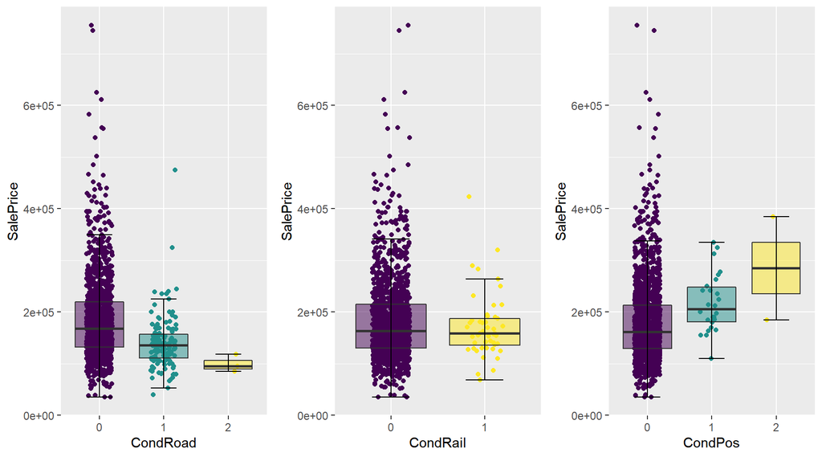

```r
p1 <- d %>% ggplot(aes(x = CondRoad, y = SalePrice)) +
  geom_jitter(aes(color = CondRoad), width = 0.2) +
  geom_boxplot(aes(fill = CondRoad), alpha = 0.5, outlier.shape = NA) +
  stat_boxplot(geom = "errorbar", width = 0.4) +
  theme(legend.position = "none")
p2 <- d %>% ggplot(aes(x = CondRail, y = SalePrice)) +
  geom_jitter(aes(color = CondRail), width = 0.2) +
  geom_boxplot(aes(fill = CondRail), alpha = 0.5, outlier.shape = NA) +
  stat_boxplot(geom = "errorbar", width = 0.4) +
  theme(legend.position = "none")
p3 <- d %>% ggplot(aes(x = CondPos, y = SalePrice)) +
  geom_jitter(aes(color = CondPos), width = 0.2) +
  geom_boxplot(aes(fill = CondPos), alpha = 0.5, outlier.shape = NA) +
  stat_boxplot(geom = "errorbar", width = 0.4) +
  theme(legend.position = "none")
grid.arrange(p1, p2, p3, nrow = 1)
```

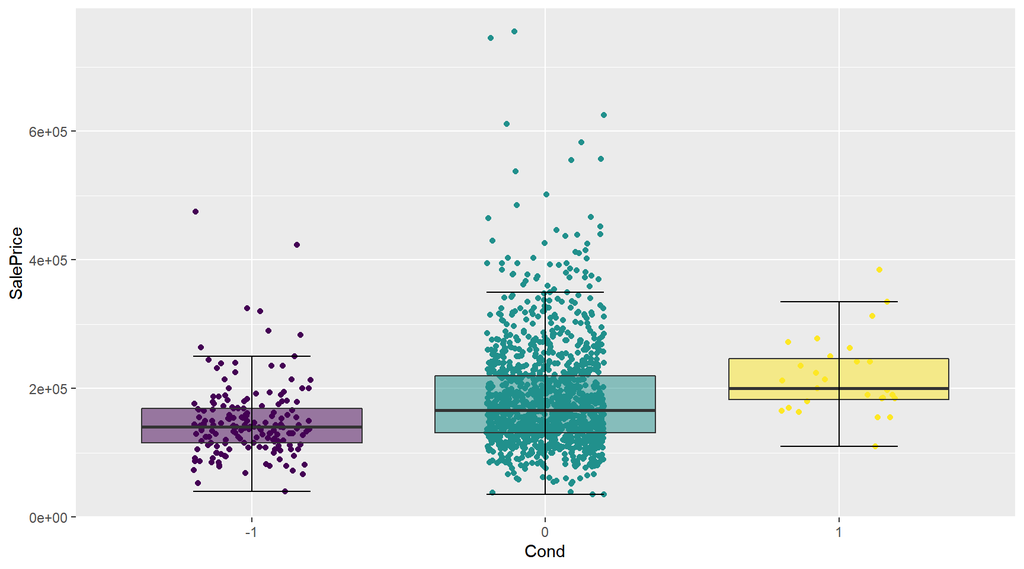

```r
ggplot(d, aes(x = Cond, y = SalePrice)) +
  geom_jitter(aes(color = Cond), width = 0.2) +
  geom_boxplot(aes(fill = Cond), alpha = 0.5, outlier.shape = NA) +
  stat_boxplot(geom = "errorbar", width = 0.4) +
  theme(legend.position = "none")
```

## `GarageYrBlt`

`GarageYrBlt` has maximum value 2207.

```r
d %>% filter(GarageYrBlt > 2010) %>% select(GarageYrBlt, YearBuilt)
```

```
##   GarageYrBlt YearBuilt
## 1        2207      2006
```

I’ll bet a nickle the garage from this home was built in 2007, not 2207.

```r
d$GarageYrBlt <- ifelse(d$GarageYrBlt == 2207, 2007, d$GarageYrBlt)
```

## Impute `NA`

There are still several variables with missing values.

```r
d %>%
  summarize_all(~ sum(is.na(.))/length(.)) %>%
  gather(key = "Column", value = "% NA") %>%
  filter(`% NA` > 0 & Column != 'SalePrice') %>%
  mutate(ColType = map_chr(Column, ~ paste(class(d[[.]]), collapse = " "))) %>%
  select(Column, ColType, `% NA`) %>%
  arrange(desc(`% NA`))
```

```
##          Column        ColType         % NA
## 1   LotFrontage        numeric 0.1664953751
## 2   GarageYrBlt        numeric 0.0544707091
## 3    MasVnrType         factor 0.0082219938
## 4    MasVnrArea        numeric 0.0078794108
## 5      MSZoning         factor 0.0013703323
## 6  BsmtFullBath        numeric 0.0006851662
## 7  BsmtHalfBath        numeric 0.0006851662
## 8    Functional ordered factor 0.0006851662
## 9     Utilities         factor 0.0006851662
## 10   BsmtFinSF1        numeric 0.0003425831
## 11   BsmtFinSF2        numeric 0.0003425831
## 12    BsmtUnfSF        numeric 0.0003425831
## 13   Electrical ordered factor 0.0003425831
## 14  Exterior1st         factor 0.0003425831
## 15  Exterior2nd         factor 0.0003425831
## 16   GarageArea        numeric 0.0003425831
## 17   GarageCars        numeric 0.0003425831
## 18  KitchenQual ordered factor 0.0003425831
## 19     SaleType         factor 0.0003425831
## 20  TotalBsmtSF        numeric 0.0003425831
```

Are there any patterns in the missing data? This plot shows the row count in the left col, which vars have missing values in the colors (red = missing), and number of vars with missing values in the right axis. E.g., 11 observations are have `NA` for both `LotFrontage` and `GarageYrBlt`.

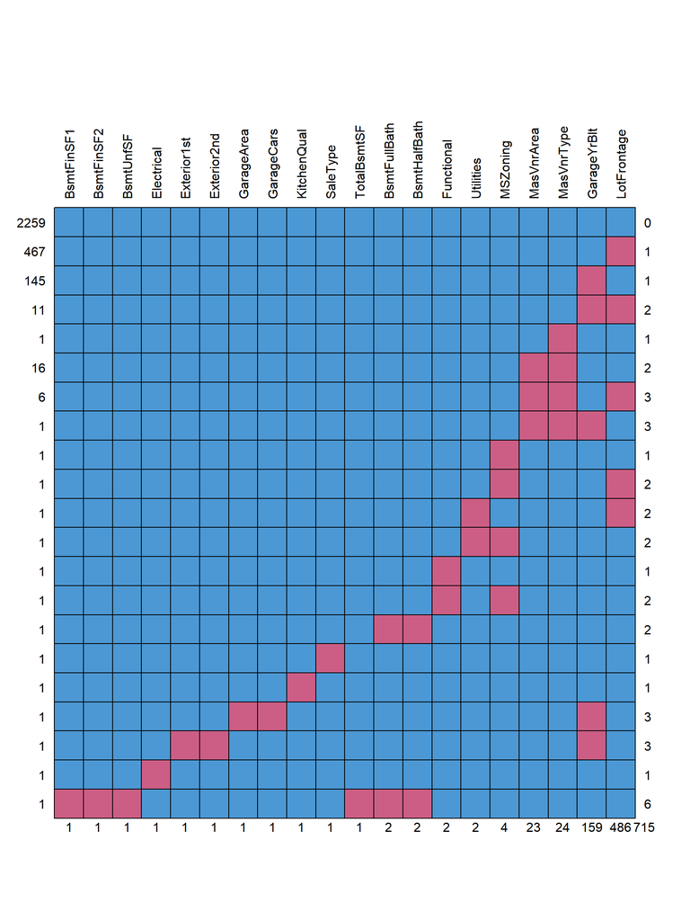

```r
invisible(md.pattern(d[,which(colnames(d) != "SalePrice")] %>%
                       select_if(~ any(is.na(.))),
                     rotate.names = TRUE))
```

In one instance, `BsmtFinSF1`, `BsmtFinSF2`, `BsmtUnfSF`, `TotalBsmtSF`, `BsmtFullBath`, and `BsmtHalfBath` are `NA` together. They are probably `NA` because the home has no basement. I’ll map these `NA`s to 0.

```r
idx <- which(is.na(d$BsmtFullBath) & is.na(d$BsmtHalfBath) & is.na(d$BsmtFinSF1) &
               is.na(d$BsmtFinSF2) & is.na(d$BsmtUnfSF) & is.na(d$BsmtUnfSF) & is.na(d$TotalBsmtSF))
d[idx, "BsmtFullBath"] <- 0
d[idx, "BsmtHalfBath"] <- 0
d[idx, "BsmtFinSF1"] <- 0
d[idx, "BsmtFinSF2"] <- 0
d[idx, "BsmtUnfSF"] <- 0
d[idx, "TotalBsmtSF"] <- 0
rm(idx)
```

```r
# d %>% filter(is.na(MasVnrType)) %>% select(MasVnrArea)
d <- d %>%
  mutate(MasVnrType = ifelse(is.na(MasVnrArea) & is.na(MasVnrType), "None", as.character(MasVnrType)),
         MasVnrArea = ifelse(is.na(MasVnrArea) & is.na(MasVnrType), 0, MasVnrArea))
d$MasVnrType <- parse_factor(d$MasVnrType, levels = UF.levels$MasVnrType)
```

In one istance, `GarageArea`, `GarageCars`, and `GarageYrBlt` are `NA` together.  
They are probably `NA` because the home has no garage.

```r
idx <- which(is.na(d$GarageArea) & is.na(d$GarageCars) & is.na(d$GarageYrBlt))
d[idx, "GarageArea"] <- 0
d[idx, "GarageCars"] <- 0
d[idx, "GarageYrBlt"] <- min(d$GarageYrBlt, na.rm = TRUE)
rm(idx)
```

```r
skimr::skim_to_wide(d[is.na(d$GarageYrBlt),
                      which(colnames(d) %in% c("GarageArea", "GarageCars", "GarageCond",
                                               "GarageFinish", "GarageQual", "GarageType"))])
```

```
## # A tibble: 6 x 16
##   type  variable missing complete n     n_unique top_counts ordered mean
##   <chr> <chr>    <chr>   <chr>    <chr> <chr>    <chr>      <chr>   <chr>
## 1 fact~ GarageC~ 0       158      158   1        NA: 158, ~ TRUE    <NA>
## 2 fact~ GarageF~ 0       158      158   1        NA: 158, ~ TRUE    <NA>
## 3 fact~ GarageQ~ 0       158      158   1        NA: 158, ~ TRUE    <NA>
## 4 fact~ GarageT~ 0       158      158   2        NA: 157, ~ FALSE   <NA>
## 5 nume~ GarageA~ 0       158      158   <NA>     <NA>       <NA>    "2.2~
## 6 nume~ GarageC~ 0       158      158   <NA>     <NA>       <NA>    0.00~
## # ... with 7 more variables: sd <chr>, p0 <chr>, p25 <chr>, p50 <chr>,
## #   p75 <chr>, p100 <chr>, hist <chr>
```

Seems like it. In cases where all seven garage vars are “NA” or `NA`, set `GarageYrBlt` to the oldest year in the data set under the logic that no garage is about as valuable as the oldest possible garage.

```r
d$GarageYrBlt <- case_when(is.na(d$GarageYrBlt) & d$GarageArea == 0 & d$GarageCars == 0 &
                             d$GarageCond == "NA" & d$GarageFinish == "NA" & d$GarageQual == "NA" &
                             d$GarageType == "NA" ~ min(d$GarageYrBlt, na.rm = TRUE),
                           TRUE ~ d$GarageYrBlt)
```

Check the pattern one more time.

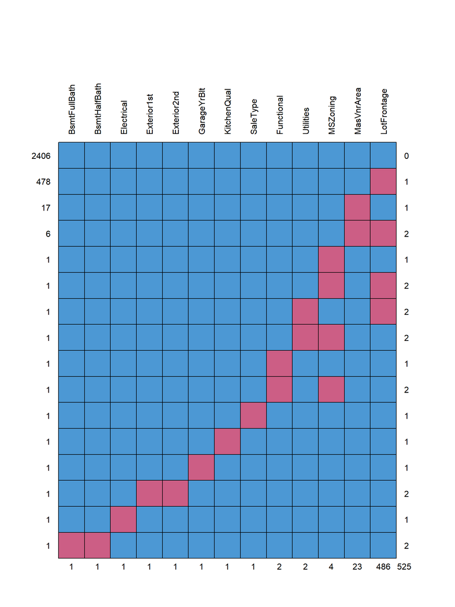

```r
invisible(md.pattern(d[,which(colnames(d) != "SalePrice")] %>%
                       select_if(~ any(is.na(.))),
                     rotate.names = TRUE))
```

Use MICE to impute values for `NA`. (see discussion of algorithm [here](https://www.ncbi.nlm.nih.gov/pmc/articles/PMC3074241/).

```r
imp <- mice(d,
            predictorMatrix = quickpred(d, exclude = c("Set", "Id")),
            seed = 1970,
            method = "cart",
            maxit = 1)
```

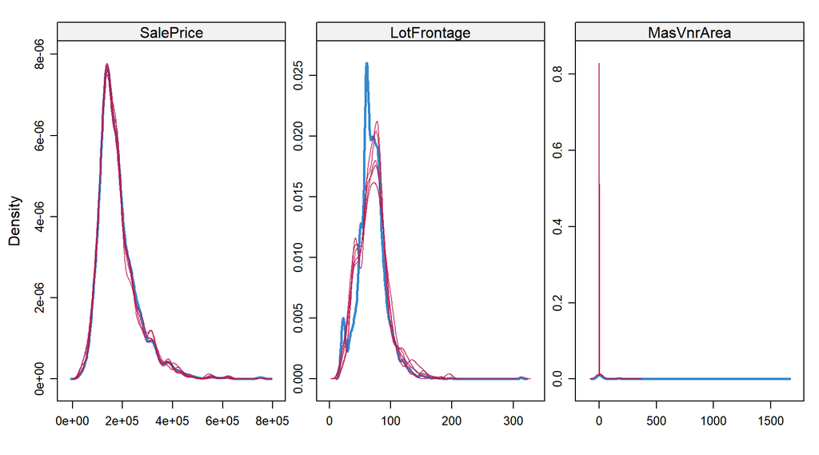

```r
densityplot(imp)
```

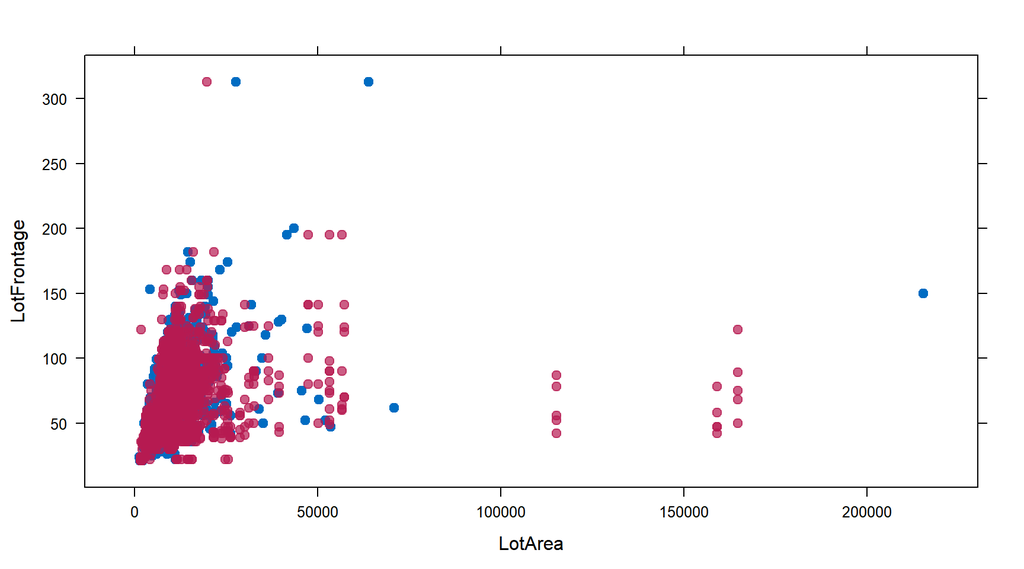

```r
xyplot(imp, LotFrontage ~ LotArea, col=mdc(1:2), pch=20, cex=1.5)
```

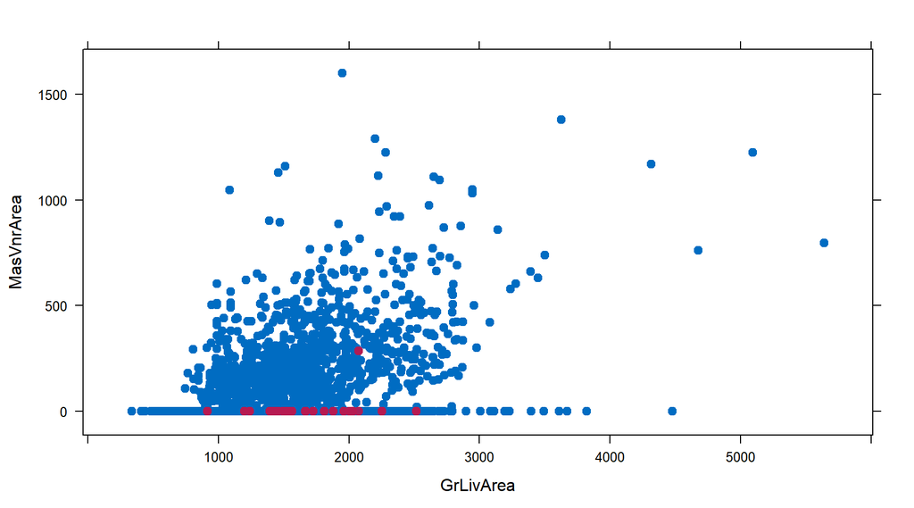

```r
xyplot(imp, MasVnrArea ~ GrLivArea, col=mdc(1:2), pch=20, cex=1.5)
```

Complete the data set with missing values replaced by imputations.

```r
d <- complete(imp)
```

```r
d %>% skimr::skim_to_wide() %>% filter(as.numeric(missing) > 0)
```

```
## # A tibble: 0 x 19
## # ... with 19 variables: type <chr>, variable <chr>, missing <chr>,
## #   complete <chr>, n <chr>, min <chr>, max <chr>, empty <chr>,
## #   n_unique <chr>, top_counts <chr>, ordered <chr>, mean <chr>, sd <chr>,
## #   p0 <chr>, p25 <chr>, p50 <chr>, p75 <chr>, p100 <chr>, hist <chr>
```

…but set the test set `SalePrice` values back to `NA`!

```r
d$SalePrice <- ifelse(d$Set == "test", NA, d$SalePrice)
```

Here is one more look at the data set.

```r
skimr::skim_to_wide(d)[, c(1:3, 9, 14, 16, 18, 19)] %>% knitr::kable()
```

| type | variable | missing | n_unique | p0 | p50 | p100 | hist |
| --- | --- | --- | --- | --- | --- | --- | --- |
| character | Set | 0 | 2 | NA | NA | NA | NA |
| factor | Alley | 0 | 3 | NA | NA | NA | NA |
| factor | BldgType | 0 | 5 | NA | NA | NA | NA |
| factor | BsmtCond | 0 | 5 | NA | NA | NA | NA |
| factor | BsmtExposure | 0 | 5 | NA | NA | NA | NA |
| factor | BsmtFinType1 | 0 | 7 | NA | NA | NA | NA |
| factor | BsmtFinType2 | 0 | 7 | NA | NA | NA | NA |
| factor | BsmtQual | 0 | 5 | NA | NA | NA | NA |
| factor | CentralAir | 0 | 2 | NA | NA | NA | NA |
| factor | Cond | 0 | 3 | NA | NA | NA | NA |
| factor | Condition1 | 0 | 9 | NA | NA | NA | NA |
| factor | Condition2 | 0 | 8 | NA | NA | NA | NA |
| factor | CondPos | 0 | 3 | NA | NA | NA | NA |
| factor | CondRail | 0 | 2 | NA | NA | NA | NA |
| factor | CondRoad | 0 | 3 | NA | NA | NA | NA |
| factor | Electrical | 0 | 5 | NA | NA | NA | NA |
| factor | ExterCond | 0 | 5 | NA | NA | NA | NA |
| factor | Exterior1st | 0 | 15 | NA | NA | NA | NA |
| factor | Exterior2nd | 0 | 15 | NA | NA | NA | NA |
| factor | ExterQual | 0 | 4 | NA | NA | NA | NA |
| factor | Fence | 0 | 5 | NA | NA | NA | NA |
| factor | FireplaceQu | 0 | 6 | NA | NA | NA | NA |
| factor | Foundation | 0 | 6 | NA | NA | NA | NA |
| factor | Functional | 0 | 7 | NA | NA | NA | NA |
| factor | GarageCond | 0 | 6 | NA | NA | NA | NA |
| factor | GarageFinish | 0 | 4 | NA | NA | NA | NA |
| factor | GarageQual | 0 | 6 | NA | NA | NA | NA |
| factor | GarageType | 0 | 7 | NA | NA | NA | NA |
| factor | Heating | 0 | 6 | NA | NA | NA | NA |
| factor | HeatingQC | 0 | 5 | NA | NA | NA | NA |

[output cut: 56 more lines]

# Save Work

Save the data as an input to the next step, exploratory data analysis

```r
saveRDS(d, file = "./ames_01.RDS")
```